# The LightSpeed Cinemas

## 1. Context

The management of a chain of cinemas called Light Speed cinemas are interested in reviewing the data for the 3 cinemas for the past 3 months. The data regards the total number of ticket sales they have made, along with the number of sales and revenue for the concession stand (Soda, Popcorn, and Candy). In particular, the management are interested in **comparing the revenue of the concession stand between the three cinemas**.

As a result of an interview with the management of Lightspeed Cinemas, the following meeting notes have been compiled in order to better understand the context:

1. the management is not sure about which cinema is performing the best, but thinks that it might be **the one that sells the products for the highest price**;
2. similarly, the management thinks that the most successful concession is **the one that sold the most products**;
3. the cinemas don’t have any say on what movies get made, and how they’re advertised and how an audience will review them – they can only sell tickets to whatever movie is out. Whenever they sell a ticket, a large portion of it goes to the movie studio, then from what is left, once the cost of running the cinema has been considered, profit margins on ticket sales are slim. So **the main revenue they generate is from the concession stand**. Their objective is **to maximise revenue at the concession stand for each ticket sold**. In other words, they want to understand **which cinema generates the most revenue per customer at the concession stand**;
4. they'd like to be able to clearly identify which cinema was the best, and what factors made it the best.

The objective of this report is **to review the data and the context provided, and to highlight which of the three cinemas has the most successful concession stand, and how the others compare to it**.

## 2. Resources

The data has been collected and organized in three small datasets, namely:

- `lightspeed-cinema-product-cost.csv`: the price each of the cinemas charges for the items they sell at the concession stand;
- `lightspeed-month-cinema-product-sales-revenue.csv`: the monthly sales number and revenue for each of the items each cinema sells at the concession stand;
- `lightspeed-month-cinema-tickets.csv`: the number of tickets sold for each of the three cinemas of the three months.

## 3. Exploratory data analysis

### 3.1 Import the libraries

```python
import numpy as np
import pandas as pd
from matplotlib import pyplot as plt
import seaborn as sns
```

### 3.2 Load the data

```python
price_per_item = pd.read_csv("lightspeed-cinema-product-cost.csv", sep=";")
monthly_sales = pd.read_csv("lightspeed-month-cinema-product-sales-revenue.csv", sep=";")
ticket_number = pd.read_csv("lightspeed-month-cinema-tickets.csv", sep=";")
```

### 3.3 Point 1: the highest price

The first point of interest raised by the client and addressed in the Context section is:

> The management is not sure about which cinema is performing the best, but thinks that it might be **the one that sells the products for the highest price**

As a first approach, we might want to better understand which is the cinema that sells the products for the highest price.

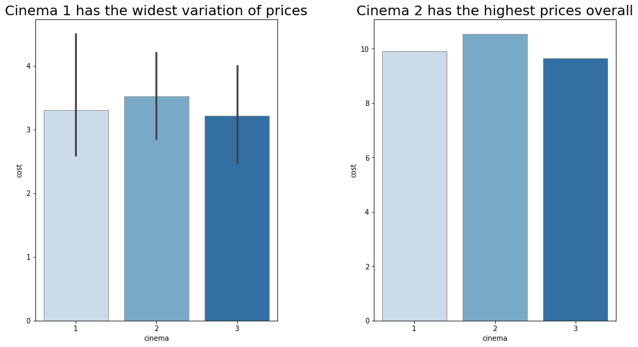

```python
total_price = price_per_item[['cinema', 'cost']]
total_price = total_price.groupby('cinema').agg({'cost': 'sum'}).reset_index()

fig = plt.figure(figsize=(15, 8))
fig.subplots_adjust(hspace=0.4, wspace=0.4)

ax = fig.add_subplot(1, 2, 1)
ax.set_title('Cinema 1 has the widest variation of prices', fontsize=20)
sns.barplot(x="cinema", y="cost",
            palette="Blues", edgecolor=".6",
            data=price_per_item)

ax = fig.add_subplot(1, 2, 2)
ax.set_title('Cinema 2 has the highest prices overall', fontsize=20)
sns.barplot(x="cinema", y="cost",
            palette="Blues", edgecolor=".6",
            data=total_price)
```

The first graph shows that Cinema 1 has the widest variation of prices between products. However, the second graph shows that the cinema charging the highest prices is **Cinema 2**, since the cost of all its items added together is higher than the cost of the items sold by the other two.

### 3.4 Point 2: the total sales

The second point of interest raised by the client is:

> similarly, the management thinks that the most successful concession is **the one that sold the most products**

Let us plot the total number of sales per cinema.

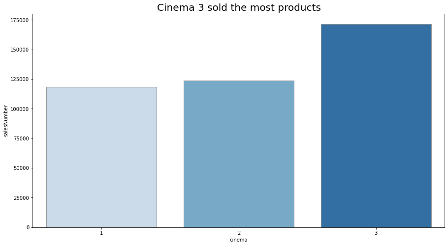

```python
total_sales = monthly_sales[['cinema', 'salesNumber']]
total_sales = total_sales.groupby('cinema').agg({'salesNumber': 'sum'}).reset_index()

f, ax = plt.subplots(figsize=(15, 8))
ax.set_title('Cinema 3 sold the most products', fontsize=20)

g=sns.barplot(x="cinema", y="salesNumber",
            palette="Blues",
            edgecolor=".6",
            data=total_sales)
```

We can see that Cinema 1 sold the least amount of products. Cinema 2 did slightly better, but **Cinema 3** sold a lot more items than both the other two.

### 3.5 Point 3: the total revenue generated and the total number of tickets sold

We also know that, according to the third point raised by the client, the revenue is a fundamental indicator of success. Let us see the total revenue generated by the cinemas during the last three months of activity. Although we know that ticket sales are not very relevant to the success of a cinema, we still might be interested in seeing how well the three cinemas fare in that regard.

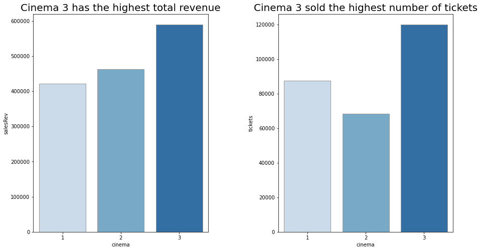

```python
total_rev = monthly_sales[['cinema', 'salesRev']]
total_rev = total_rev.groupby(['cinema']).agg({'salesRev':'sum'}).reset_index()

total_tickets = ticket_number[['cinema', 'tickets']]
total_tickets = total_tickets.groupby(['cinema']).agg({'tickets':'sum'}).reset_index()

fig = plt.figure(figsize=(15, 8))
fig.subplots_adjust(hspace=0.4, wspace=0.4)

ax = fig.add_subplot(1, 2, 1)
ax.set_title('Cinema 3 has the highest total revenue', fontsize=20)
sns.barplot(x="cinema", y="salesRev",
            palette="Blues", edgecolor=".6",
            data=total_rev)

ax = fig.add_subplot(1, 2, 2)
ax.set_title('Cinema 3 sold the highest number of tickets', fontsize=20)
g=sns.barplot(x="cinema", y="tickets",
            palette="Blues", edgecolor=".6",
            data=total_tickets)
```

As we can see, **Cinema 3** is, again, superior to the others in terms of total revenue and ticket sales.

Cinema 3 is selling the most, making the highest total revenue and selling the highest number of tickets. But, is it the most successful?

### 3.6 Point 4: the average revenue per ticket sold

If we read through the meeting notes, we should notice that the actual measure of success is the **revenue per ticket**. This is because the objective of LightSpeed is to maximise the amount of revenue it makes from the concession stand *for each consumer that comes in*, since the profit margin for tickets is extremely thin.

The first graph (the one about the highest price), coupled with the graph below (created by dividing the total revenue by the total number of tickets), tells a quite different story.

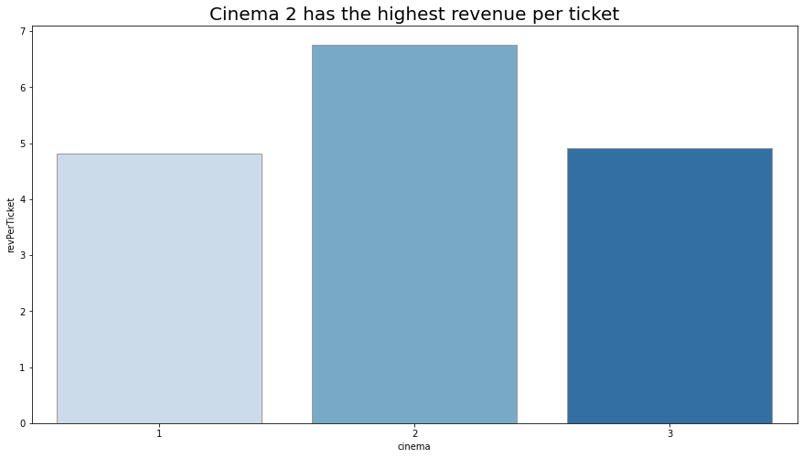

```python
rev_per_ticket = pd.merge(total_rev, total_tickets, on="cinema")

def get_revPerTicket(datafr):
    datafr['revPerTicket'] = datafr['salesRev'] / datafr['tickets']
    return datafr

rev_per_ticket = rev_per_ticket.groupby(['cinema']).apply(get_revPerTicket)

f, ax = plt.subplots(figsize=(15, 8))
ax.set_title('Cinema 2 has the highest revenue per ticket', fontsize=20)

g=sns.barplot(x="cinema", y="revPerTicket",
            palette="Blues", edgecolor=".6",
            data=rev_per_ticket)
```

On one hand, Cinema 1 and Cinema 3 generate almost the same amount of revenue per customer. On the other, Cinema 2 generates much more value per customer. Based on our client's indications, we can say that **Cinema 2** is therefore the best performing cinema in terms of revenue generated per customer. This is due to the fact it charges the highest prices for its products.

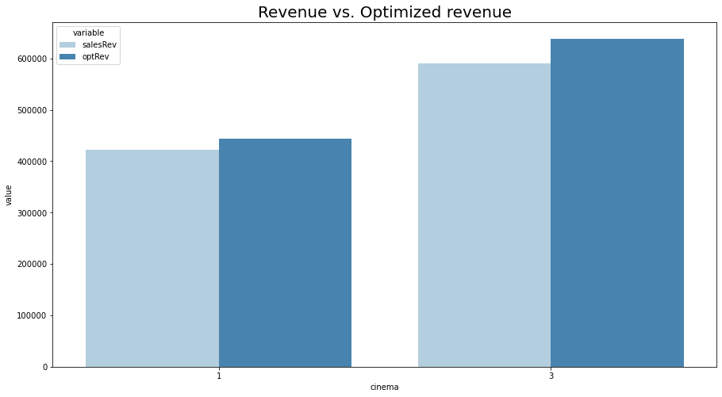

```python
price_per_item['opt_cost'] = price_per_item['cost'].replace([4.50, 2.80, 2.60, 4.00, 3.15, 2.49], [4.20, 3.50, 2.85, 4.20, 3.50, 2.85])
price_per_item
opt_monthly_sales = monthly_sales[['cinema', 'product', 'salesNumber', 'salesRev']]
opt_monthly_sales
dset = pd.merge(price_per_item, opt_monthly_sales, on=["cinema", "product"])
dset

def get_opt_rev(datafr):
    datafr['optRev'] = datafr['opt_cost'] * datafr['salesNumber']
    return datafr

opt_rev = dset.groupby(['cinema']).apply(get_opt_rev)
opt_rev = opt_rev[['cinema', 'optRev']]
opt_rev = opt_rev.groupby('cinema').agg({'optRev': 'sum'}).reset_index()
revenues = pd.merge(total_rev, opt_rev, on='cinema')
revenues = revenues.drop(1)
revenues2 = revenues[['salesRev', 'optRev']]

rev_melt = pd.melt(revenues2)
rev_melt

cinemas = ['1', '3', '1', '3']
rev_melt['cinema'] = cinemas
rev_melt

f, ax = plt.subplots(figsize=(15, 8))
ax.set_title('Revenue vs. Optimized revenue', fontsize=20)
sns.barplot(data=rev_melt, x="cinema", y="value", hue="variable", palette="Blues")
```

## 4. Summary and Outcomes

Given the contextual information, by comparing the sales and revenue data of the three cinemas, it is evident that the most successful cinema is Cinema 2 in terms of revenue generated per customer.

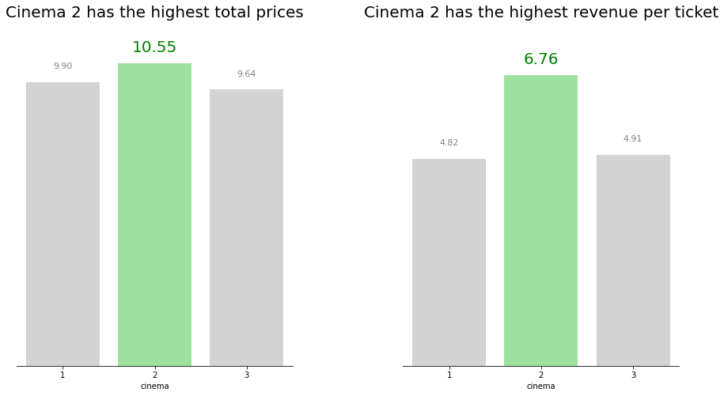

```python
fig = plt.figure(figsize=(15, 8))
fig.subplots_adjust(hspace=0.4, wspace=0.4)

rev_per_ticket = pd.merge(total_rev, total_tickets, on="cinema")
rev_per_ticket

def get_revPerTicket(datafr):
    datafr['revPerTicket'] = datafr['salesRev'] / datafr['tickets']
    return datafr

rev_per_ticket = rev_per_ticket.groupby(['cinema']).apply(get_revPerTicket)

color=['lightgray', 'lightgreen', 'lightgray']

ax = fig.add_subplot(1, 2, 1)
ax.set_title('Cinema 2 has the highest total prices', fontsize=20)
g=sns.barplot(x="cinema", y="cost",
            palette=color,
            data=total_price)
ax=g
for p in ax.patches:
    if p == ax.patches[0] or p == ax.patches[2]:
             ax.annotate("%.2f" % p.get_height(), (p.get_x() + p.get_width() / 2., p.get_height()),
                 ha='center', va='center', fontsize=11, color='gray', xytext=(0, 20),
                 textcoords='offset points')
    else:
        ax.annotate("%.2f" % p.get_height(), (p.get_x() + p.get_width() / 2., p.get_height()),
                 ha='center', va='center', fontsize=20, color='green', xytext=(0, 20),
                 textcoords='offset points')
_ = g.set_ylim(0,12)
g.set(yticks=[])
sns.despine(left=True)
ax.set_ylabel('')

ax = fig.add_subplot(1, 2, 2)
ax.set_title('Cinema 2 has the highest revenue per ticket', fontsize=20)
g=sns.barplot(x="cinema", y="revPerTicket",
            palette=color,
            data=rev_per_ticket)
ax=g

for p in ax.patches:
    if p == ax.patches[0] or p == ax.patches[2]:
        ax.annotate("%.2f" % p.get_height(), (p.get_x() + p.get_width() / 2., p.get_height()),
                 ha='center', va='center', fontsize=11, color='gray', xytext=(0, 20),
                 textcoords='offset points')
    else:
        ax.annotate("%.2f" % p.get_height(), (p.get_x() + p.get_width() / 2., p.get_height()),
                 ha='center', va='center', fontsize=20, color='green', xytext=(0, 20),
                 textcoords='offset points')
_ = g.set_ylim(0,8)

g.set(yticks=[])
sns.despine(left=True)
ax.set_ylabel('')
```

By looking at the information about product prices and revenue per ticket, we can infer that **customers are probably willing to spend more money on the items sold at the concession stands**, thus **product prices in Cinema 1 and 3 can be slightly raised to meet the prices of Cinema 2 in order to generate more revenue.**

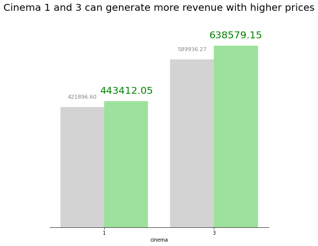

```python
fig = plt.figure(figsize=(8, 8))

color=['lightgray', 'lightgreen', 'lightgray', 'lightgreen']

g=sns.barplot(data=rev_melt, x="cinema", y="value", hue="variable", palette=color)
ax=g

for p in ax.patches:
    if p == ax.patches[0] or p == ax.patches[1]:
        ax.annotate("%.2f" % p.get_height(), (p.get_x() + p.get_width() / 2., p.get_height()),
                 ha='center', va='center', fontsize=11, color='gray', xytext=(0, 20),
                 textcoords='offset points')
    else:
        ax.annotate("%.2f" % p.get_height(), (p.get_x() + p.get_width() / 2., p.get_height()),
                 ha='center', va='center', fontsize=20, color='green', xytext=(0, 20),
                 textcoords='offset points')
_ = g.set_ylim(0,750000)

g.set(yticks=[])
sns.despine(left=True)
g.legend([],[], frameon=False)
ax.set_ylabel('')

plt.title('Cinema 1 and 3 can generate more revenue with higher prices', fontsize=20)
```